# Lab5

Marlee_Galloway

9/23/2020

```r
library(tidyverse)
```

###Joining Tables

```r
Confirmed_State_3_13 <-   read_csv(url("https://raw.githubusercontent.com/CSSEGISandData/COVID-19/master/csse_covid_19_data/csse_covid_19_daily_reports/03-13-2020.csv")) %>%
  rename(Country_Region = "Country/Region", Province_State = "Province/State") %>%
  filter (Country_Region == "US") %>%
  group_by(Province_State, Country_Region) %>%
  summarise(Confirmed = sum(Confirmed))
str(Confirmed_State_3_13)
```

[output not shown]

```r
Confirmed_State_9_13 <-   read_csv(url("https://raw.githubusercontent.com/CSSEGISandData/COVID-19/master/csse_covid_19_data/csse_covid_19_daily_reports/09-13-2020.csv")) %>%
  filter (Country_Region == "US") %>%
  group_by(Province_State, Country_Region) %>%
  summarise(Confirmed = sum(Confirmed))
str(Confirmed_State_9_13)
```

[output not shown]

[output cut: 12 more lines]

[output not shown]

```r
setdiff(Confirmed_State_9_13$Province_State, Confirmed_State_3_13$Province_State)
```

```
## [1] "Guam"                     "Northern Mariana Islands"
## [3] "Puerto Rico"              "Recovered"
## [5] "Virgin Islands"
```

```r
Confirmed_State_9_13 <- Confirmed_State_9_13 %>%
  filter(Province_State != "Recovered")
```

```r
Confirmed_State_3_13_9_13_joined <- full_join(Confirmed_State_3_13,
      Confirmed_State_9_13, by = c("Province_State"))
head(Confirmed_State_3_13_9_13_joined)
```

```
## # A tibble: 6 x 5
## # Groups:   Province_State [6]
##   Province_State Country_Region.x Confirmed.x Country_Region.y Confirmed.y
##   <chr>          <chr>                  <dbl> <chr>                  <dbl>
## 1 Alabama        US                         5 US                    138755
## 2 Alaska         US                         1 US                      6268
## 3 Arizona        US                         9 US                    208512
## 4 Arkansas       US                         6 US                     70219
## 5 California     US                       282 US                    761728
## 6 Colorado       US                        49 US                     61293
```

```r
tail(Confirmed_State_3_13_9_13_joined, 5)
```

```
## # A tibble: 5 x 5
## # Groups:   Province_State [5]
##   Province_State       Country_Region.x Confirmed.x Country_Region.y Confirmed.y
##   <chr>                <chr>                  <dbl> <chr>                  <dbl>
## 1 Wyoming              US                         1 US                      4346
## 2 Guam                 <NA>                      NA US                      1863
## 3 Northern Mariana Is… <NA>                      NA US                        60
## 4 Puerto Rico          <NA>                      NA US                     37380
## 5 Virgin Islands       <NA>                      NA US                      1220
```

#or

```r
which(is.na(Confirmed_State_3_13_9_13_joined))
```

```
## [1] 111 112 113 114 168 169 170 171
```

#Rename and delete columns:

```r
Confirmed_State_3_13_9_13_joined <- full_join(Confirmed_State_3_13,
      Confirmed_State_9_13, by = c("Province_State")) %>%
      rename(Confirmed_3_13_2020 = "Confirmed.x", Confirmed_9_13_2020 = "Confirmed.y") %>%
      select(-Country_Region.x, -Country_Region.y) %>%
      replace_na(list(Confirmed_3_13_2020 = 0))
head(Confirmed_State_3_13_9_13_joined)
```

```
## # A tibble: 6 x 3
## # Groups:   Province_State [6]
##   Province_State Confirmed_3_13_2020 Confirmed_9_13_2020
##   <chr>                        <dbl>               <dbl>
## 1 Alabama                          5              138755
## 2 Alaska                           1                6268
## 3 Arizona                          9              208512
## 4 Arkansas                         6               70219
## 5 California                     282              761728
## 6 Colorado                        49               61293
```

```r
which(is.na(Confirmed_State_3_13_9_13_joined))
```

```
## integer(0)
```

###Switching Between Wide and Long Table Formats

```r
Confirmed_State_3_13_9_13_joined_long <- Confirmed_State_3_13_9_13_joined %>%
              pivot_longer(-c(Province_State),
                            names_to = "Date", values_to = "Confirmed")
```

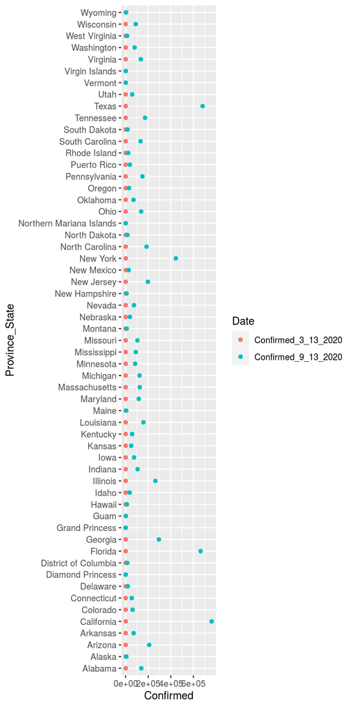

```r
# to adjust figure size {r, fig.width = 5, fig.height = 10}
ggplot(Confirmed_State_3_13_9_13_joined_long, aes(x = Confirmed,  y = Province_State))  +
    geom_point(aes(color = Date))
```

###Working With the Time Series Data

#Most recent data for confirmed cases:

```r
time_series_confirmed <- read_csv(url("https://raw.githubusercontent.com/CSSEGISandData/COVID-19/master/csse_covid_19_data/csse_covid_19_time_series/time_series_covid19_confirmed_global.csv")) %>%
  rename(Province_State = "Province/State", Country_Region = "Country/Region")
 download.file(url="https://raw.githubusercontent.com/CSSEGISandData/COVID-19/master/csse_covid_19_data/csse_covid_19_time_series/time_series_covid19_confirmed_global.csv",
               destfile = "data/time_series_covid19_confirmed_global.csv")
```

```r
time_series_confirmed <- read_csv("data/time_series_covid19_confirmed_global.csv")%>%
  rename(Province_State = "Province/State", Country_Region = "Country/Region")
head(time_series_confirmed)
```

```
## # A tibble: 6 x 254
##   Province_State Country_Region   Lat   Long `1/22/20` `1/23/20` `1/24/20`
##   <chr>          <chr>          <dbl>  <dbl>     <dbl>     <dbl>     <dbl>
## 1 <NA>           Afghanistan     33.9  67.7          0         0         0
## 2 <NA>           Albania         41.2  20.2          0         0         0
## 3 <NA>           Algeria         28.0   1.66         0         0         0
## 4 <NA>           Andorra         42.5   1.52         0         0         0
## 5 <NA>           Angola         -11.2  17.9          0         0         0
## 6 <NA>           Antigua and B…  17.1 -61.8          0         0         0
## # … with 247 more variables: `1/25/20` <dbl>, `1/26/20` <dbl>, `1/27/20` <dbl>,
## #   `1/28/20` <dbl>, `1/29/20` <dbl>, `1/30/20` <dbl>, `1/31/20` <dbl>,
## #   `2/1/20` <dbl>, `2/2/20` <dbl>, `2/3/20` <dbl>, `2/4/20` <dbl>,
## #   `2/5/20` <dbl>, `2/6/20` <dbl>, `2/7/20` <dbl>, `2/8/20` <dbl>,
## #   `2/9/20` <dbl>, `2/10/20` <dbl>, `2/11/20` <dbl>, `2/12/20` <dbl>,
## #   `2/13/20` <dbl>, `2/14/20` <dbl>, `2/15/20` <dbl>, `2/16/20` <dbl>,
## #   `2/17/20` <dbl>, `2/18/20` <dbl>, `2/19/20` <dbl>, `2/20/20` <dbl>,
## #   `2/21/20` <dbl>, `2/22/20` <dbl>, `2/23/20` <dbl>, `2/24/20` <dbl>,
## #   `2/25/20` <dbl>, `2/26/20` <dbl>, `2/27/20` <dbl>, `2/28/20` <dbl>,
## #   `2/29/20` <dbl>, `3/1/20` <dbl>, `3/2/20` <dbl>, `3/3/20` <dbl>,
## #   `3/4/20` <dbl>, `3/5/20` <dbl>, `3/6/20` <dbl>, `3/7/20` <dbl>,
## #   `3/8/20` <dbl>, `3/9/20` <dbl>, `3/10/20` <dbl>, `3/11/20` <dbl>,
## #   `3/12/20` <dbl>, `3/13/20` <dbl>, `3/14/20` <dbl>, `3/15/20` <dbl>,
## #   `3/16/20` <dbl>, `3/17/20` <dbl>, `3/18/20` <dbl>, `3/19/20` <dbl>,
## #   `3/20/20` <dbl>, `3/21/20` <dbl>, `3/22/20` <dbl>, `3/23/20` <dbl>,
## #   `3/24/20` <dbl>, `3/25/20` <dbl>, `3/26/20` <dbl>, `3/27/20` <dbl>,
## #   `3/28/20` <dbl>, `3/29/20` <dbl>, `3/30/20` <dbl>, `3/31/20` <dbl>,
## #   `4/1/20` <dbl>, `4/2/20` <dbl>, `4/3/20` <dbl>, `4/4/20` <dbl>,
## #   `4/5/20` <dbl>, `4/6/20` <dbl>, `4/7/20` <dbl>, `4/8/20` <dbl>,
## #   `4/9/20` <dbl>, `4/10/20` <dbl>, `4/11/20` <dbl>, `4/12/20` <dbl>,
## #   `4/13/20` <dbl>, `4/14/20` <dbl>, `4/15/20` <dbl>, `4/16/20` <dbl>,
## #   `4/17/20` <dbl>, `4/18/20` <dbl>, `4/19/20` <dbl>, `4/20/20` <dbl>,
## #   `4/21/20` <dbl>, `4/22/20` <dbl>, `4/23/20` <dbl>, `4/24/20` <dbl>,
## #   `4/25/20` <dbl>, `4/26/20` <dbl>, `4/27/20` <dbl>, `4/28/20` <dbl>,
## #   `4/29/20` <dbl>, `4/30/20` <dbl>, `5/1/20` <dbl>, `5/2/20` <dbl>,
## #   `5/3/20` <dbl>, …
```

#Convert data to long format:

```r
time_series_confirmed_long <- time_series_confirmed %>%
               pivot_longer(-c(Province_State, Country_Region, Lat, Long),
                            names_to = "Date", values_to = "Confirmed")
```

```r
head(time_series_confirmed_long)
```

```
## # A tibble: 6 x 6
##   Province_State Country_Region   Lat  Long Date    Confirmed
##   <chr>          <chr>          <dbl> <dbl> <chr>       <dbl>
## 1 <NA>           Afghanistan     33.9  67.7 1/22/20         0
## 2 <NA>           Afghanistan     33.9  67.7 1/23/20         0
## 3 <NA>           Afghanistan     33.9  67.7 1/24/20         0
## 4 <NA>           Afghanistan     33.9  67.7 1/25/20         0
## 5 <NA>           Afghanistan     33.9  67.7 1/26/20         0
## 6 <NA>           Afghanistan     33.9  67.7 1/27/20         0
```

#Create a table with deaths and then join the two tables:

```r
 download.file(url="https://raw.githubusercontent.com/CSSEGISandData/COVID-19/master/csse_covid_19_data/csse_covid_19_time_series/time_series_covid19_deaths_global.csv",
               destfile = "data/time_series_covid19_deaths_global.csv")
```

```r
time_series_deaths <- read_csv("data/time_series_covid19_deaths_global.csv")%>%
  rename(Province_State = "Province/State", Country_Region = "Country/Region")
```

#Convert to long format:

```r
time_series_deaths_long <- time_series_deaths %>%
               pivot_longer(-c(Province_State, Country_Region, Lat, Long),
                            names_to = "Date", values_to = "Deaths")
head(time_series_deaths_long)
```

```
## # A tibble: 6 x 6
##   Province_State Country_Region   Lat  Long Date    Deaths
##   <chr>          <chr>          <dbl> <dbl> <chr>    <dbl>
## 1 <NA>           Afghanistan     33.9  67.7 1/22/20      0
## 2 <NA>           Afghanistan     33.9  67.7 1/23/20      0
## 3 <NA>           Afghanistan     33.9  67.7 1/24/20      0
## 4 <NA>           Afghanistan     33.9  67.7 1/25/20      0
## 5 <NA>           Afghanistan     33.9  67.7 1/26/20      0
## 6 <NA>           Afghanistan     33.9  67.7 1/27/20      0
```

#Joining the time series tables:

```r
time_series_confirmed_long <- time_series_confirmed_long %>%
  unite(Key, Province_State, Country_Region, Date, sep = ".", remove = FALSE)
head(time_series_confirmed_long)
```

```
## # A tibble: 6 x 7
##   Key                 Province_State Country_Region   Lat  Long Date   Confirmed
##   <chr>               <chr>          <chr>          <dbl> <dbl> <chr>      <dbl>
## 1 NA.Afghanistan.1/2… <NA>           Afghanistan     33.9  67.7 1/22/…         0
## 2 NA.Afghanistan.1/2… <NA>           Afghanistan     33.9  67.7 1/23/…         0
## 3 NA.Afghanistan.1/2… <NA>           Afghanistan     33.9  67.7 1/24/…         0
## 4 NA.Afghanistan.1/2… <NA>           Afghanistan     33.9  67.7 1/25/…         0
## 5 NA.Afghanistan.1/2… <NA>           Afghanistan     33.9  67.7 1/26/…         0
## 6 NA.Afghanistan.1/2… <NA>           Afghanistan     33.9  67.7 1/27/…         0
```

```r
time_series_deaths_long <- time_series_deaths_long %>%
  unite(Key, Province_State, Country_Region, Date, sep = ".") %>%
  select(Key, Deaths)
```

```r
time_series_long_joined <- full_join(time_series_confirmed_long,
              time_series_deaths_long, by = c("Key")) %>%
              select(-Key)
head(time_series_long_joined)
```

```
## # A tibble: 6 x 7
##   Province_State Country_Region   Lat  Long Date    Confirmed Deaths
##   <chr>          <chr>          <dbl> <dbl> <chr>       <dbl>  <dbl>
## 1 <NA>           Afghanistan     33.9  67.7 1/22/20         0      0
## 2 <NA>           Afghanistan     33.9  67.7 1/23/20         0      0
## 3 <NA>           Afghanistan     33.9  67.7 1/24/20         0      0
## 4 <NA>           Afghanistan     33.9  67.7 1/25/20         0      0
## 5 <NA>           Afghanistan     33.9  67.7 1/26/20         0      0
## 6 <NA>           Afghanistan     33.9  67.7 1/27/20         0      0
```

```r
which(is.na(time_series_long_joined$Confirmed))
```

```
## integer(0)
```

```r
which(is.na(time_series_long_joined$Deaths))
```

```
## integer(0)
```

```r
library(lubridate)
time_series_long_joined$Date <- mdy(time_series_long_joined$Date)
```

```r
time_series_long_joined_counts <- time_series_long_joined %>%
  pivot_longer(-c(Province_State, Country_Region, Lat, Long, Date),
               names_to = "Report_Type", values_to = "Counts")
head(time_series_long_joined_counts)
```

```
## # A tibble: 6 x 7
##   Province_State Country_Region   Lat  Long Date       Report_Type Counts
##   <chr>          <chr>          <dbl> <dbl> <date>     <chr>        <dbl>
## 1 <NA>           Afghanistan     33.9  67.7 2020-01-22 Confirmed        0
## 2 <NA>           Afghanistan     33.9  67.7 2020-01-22 Deaths           0
## 3 <NA>           Afghanistan     33.9  67.7 2020-01-23 Confirmed        0
## 4 <NA>           Afghanistan     33.9  67.7 2020-01-23 Deaths           0
## 5 <NA>           Afghanistan     33.9  67.7 2020-01-24 Confirmed        0
## 6 <NA>           Afghanistan     33.9  67.7 2020-01-24 Deaths           0
```

###Making graphs from the time series data

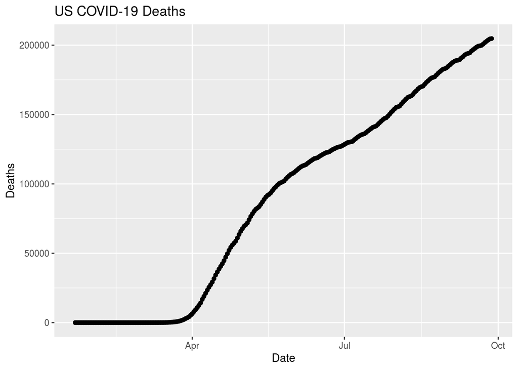

```r
time_series_long_joined %>%
  group_by(Country_Region,Date) %>%
  summarise_at(c("Confirmed", "Deaths"), sum) %>%
  filter (Country_Region == "US") %>%
    ggplot(aes(x = Date,  y = Deaths)) +
    geom_point() +
    geom_line() +
    ggtitle("US COVID-19 Deaths")
```

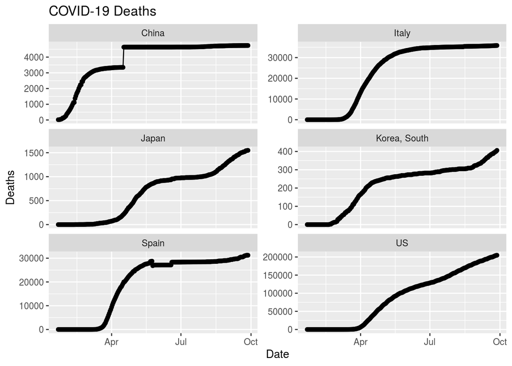

```r
time_series_long_joined %>%
  group_by(Country_Region,Date) %>%
  summarise_at(c("Confirmed", "Deaths"), sum) %>%
  filter (Country_Region %in% c("China","Japan", "Korea, South",
                                "Italy","Spain", "US")) %>%
    ggplot(aes(x = Date,  y = Deaths)) +
    geom_point() +
    geom_line() +
    ggtitle("COVID-19 Deaths") +
    facet_wrap(~Country_Region, ncol=2, scales="free_y")
```

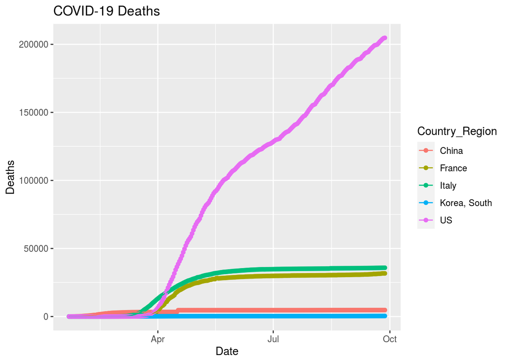

```r
time_series_long_joined %>%
    group_by(Country_Region,Date) %>%
    summarise_at(c("Confirmed", "Deaths"), sum) %>%
    filter (Country_Region %in% c("China","France","Italy",
                                "Korea, South", "US")) %>%
    ggplot(aes(x = Date,  y = Deaths, color = Country_Region)) +
    geom_point() +
    geom_line() +
    ggtitle("COVID-19 Deaths")
```

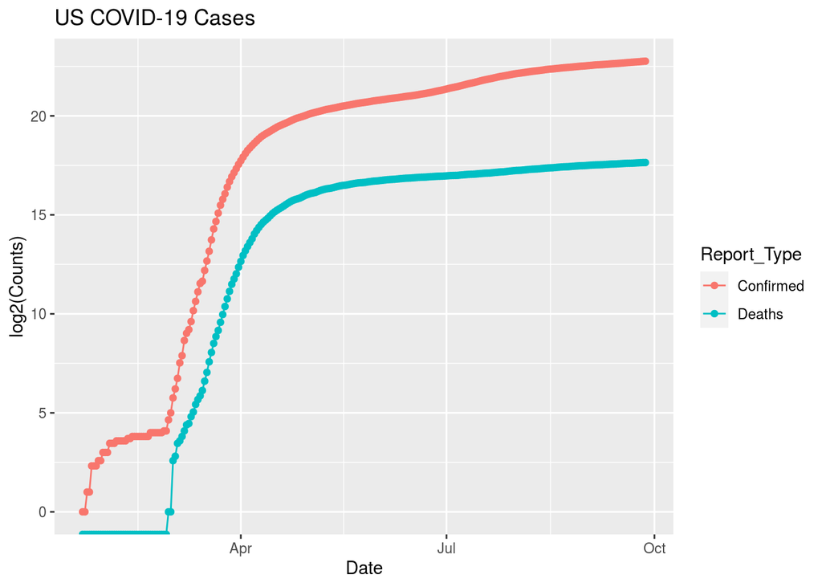

```r
time_series_long_joined_counts %>%
  group_by(Country_Region, Report_Type, Date) %>%
  summarise(Counts = sum(Counts)) %>%
  filter (Country_Region == "US") %>%
    ggplot(aes(x = Date,  y = log2(Counts), fill = Report_Type, color = Report_Type)) +
    geom_point() +
    geom_line() +
    ggtitle("US COVID-19 Cases")
```

###EXERCISES

#2.Revise the above example for joining tables using 6/13/2020 and 9/13/2020. Plot the data as a bar plot. Make sure your graph looks nice in the report by adjusting the height in the R code chunk header.

```r
Confirmed_State_6_13 <-   read_csv(url("https://raw.githubusercontent.com/CSSEGISandData/COVID-19/master/csse_covid_19_data/csse_covid_19_daily_reports/06-13-2020.csv")) %>%
  filter (Country_Region == "US") %>%
  group_by(Province_State, Country_Region) %>%
  summarise(Confirmed = sum(Confirmed))
setdiff(Confirmed_State_9_13$Province_State, Confirmed_State_6_13$Province_State)
```

```
## character(0)
```

```r
Confirmed_State_6_13_9_13_joined <- full_join(Confirmed_State_6_13,
      Confirmed_State_9_13, by = c("Province_State"))
head(Confirmed_State_6_13_9_13_joined)
```

```
## # A tibble: 6 x 5
## # Groups:   Province_State [6]
##   Province_State Country_Region.x Confirmed.x Country_Region.y Confirmed.y
##   <chr>          <chr>                  <dbl> <chr>                  <dbl>
## 1 Alabama        US                     24601 US                    138755
## 2 Alaska         US                       653 US                      6268
## 3 Arizona        US                     34660 US                    208512
## 4 Arkansas       US                     12095 US                     70219
## 5 California     US                    150018 US                    761728
## 6 Colorado       US                     29002 US                     61293
```

```r
tail(Confirmed_State_6_13_9_13_joined, 5)
```

```
## # A tibble: 5 x 5
## # Groups:   Province_State [5]
##   Province_State Country_Region.x Confirmed.x Country_Region.y Confirmed.y
##   <chr>          <chr>                  <dbl> <chr>                  <dbl>
## 1 Virginia       US                     53869 US                    133742
## 2 Washington     US                     25538 US                     79826
## 3 West Virginia  US                      2274 US                     12705
## 4 Wisconsin      US                     22518 US                     89185
## 5 Wyoming        US                      1050 US                      4346
```

```r
which(is.na(Confirmed_State_6_13_9_13_joined))
```

```
## [1] 219 277
```

```r
Confirmed_State_6_13_9_13_joined <- full_join(Confirmed_State_6_13,
      Confirmed_State_9_13, by = c("Province_State")) %>%
      rename(Confirmed_6_13_2020 = "Confirmed.x", Confirmed_9_13_2020 = "Confirmed.y") %>%
      select(-Country_Region.x, -Country_Region.y) %>%
      replace_na(list(Confirmed_6_13_2020 = 0))
head(Confirmed_State_6_13_9_13_joined)
```

```
## # A tibble: 6 x 3
## # Groups:   Province_State [6]
##   Province_State Confirmed_6_13_2020 Confirmed_9_13_2020
##   <chr>                        <dbl>               <dbl>
## 1 Alabama                      24601              138755
## 2 Alaska                         653                6268
## 3 Arizona                      34660              208512
## 4 Arkansas                     12095               70219
## 5 California                  150018              761728
## 6 Colorado                     29002               61293
```

```r
which(is.na(Confirmed_State_6_13_9_13_joined))
```

```
## [1] 161
```

```r
Confirmed_State_6_13_9_13_joined_long <- Confirmed_State_6_13_9_13_joined %>%
              pivot_longer(-c(Province_State),
                            names_to = "Date", values_to = "Confirmed")
```

```r
Confirmed_State_6_13_9_13_bar_plot <- ggplot(data = Confirmed_State_6_13_9_13_joined_long,
                       mapping = aes(x = Confirmed, y = Province_State))
```

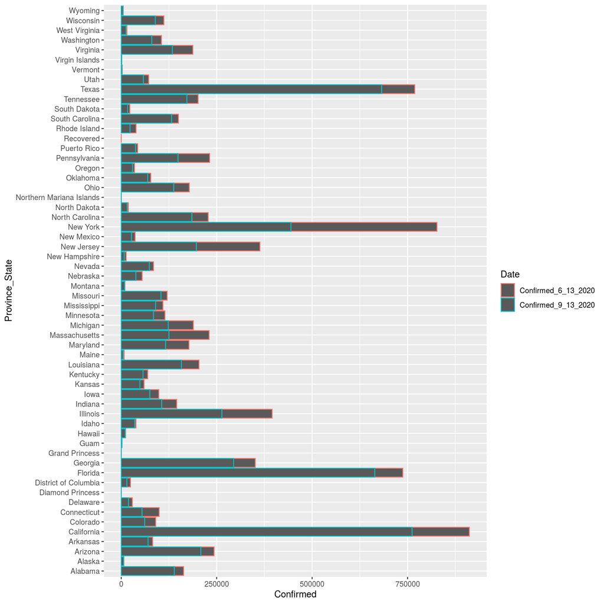

```r
Confirmed_State_6_13_9_13_bar_plot +
  geom_bar(stat = "identity", aes(color = Date))
```

#3. Add more informative x and y labels and a title to the above graph in Ex2.

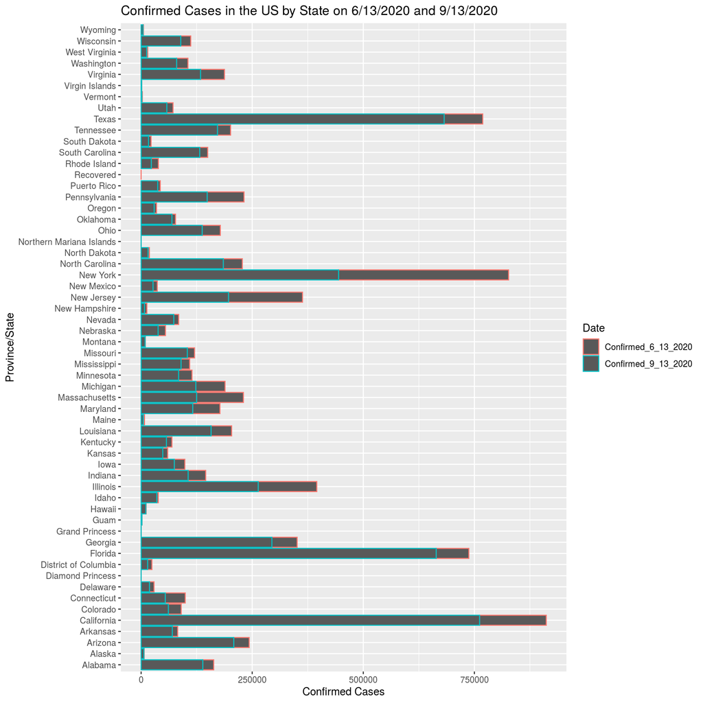

```r
Confirmed_State_6_13_9_13_bar_plot +
  geom_bar(stat = "identity", aes(color = Date)) +
   labs(title = "Confirmed Cases in the US by State on 6/13/2020 and 9/13/2020",
         x = "Confirmed Cases",
         y = "Province/State")
```

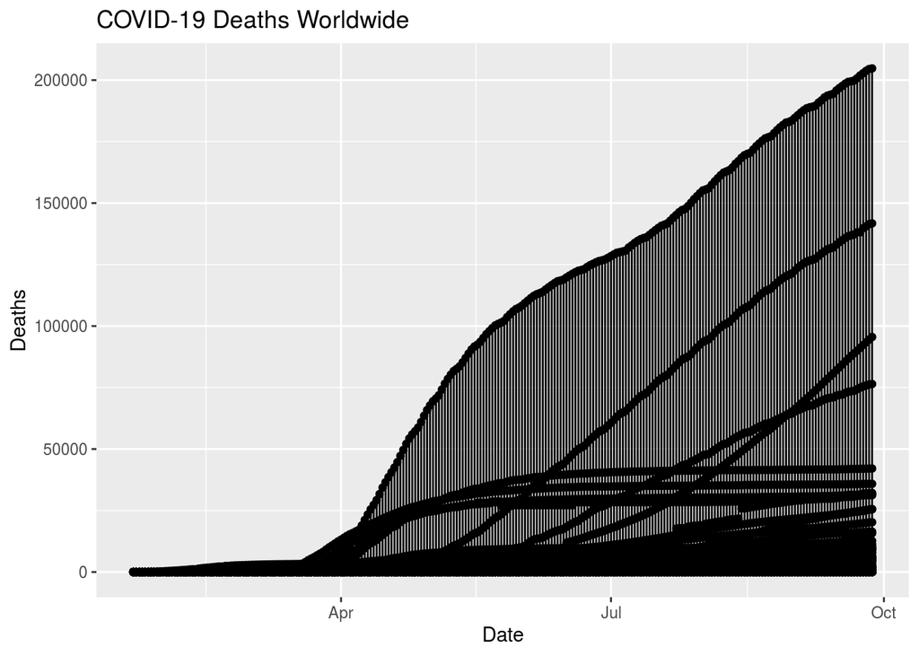

```r
time_series_long_joined %>%
  group_by(Country_Region,Date) %>%
  summarise_at(c("Deaths"), sum) %>%
    ggplot(mapping = aes(x = Date,  y = Deaths)) +
    geom_point() +
    geom_line() +
    ggtitle("COVID-19 Deaths Worldwide")
```

#5. Use Mutate to make a new column with deaths/confirmed cases (Hint: this might be best done after joining the tables, but before pivoting longer).

```r
time_series_deaths_confirmed <- time_series_long_joined %>%
  filter(!is.na(Deaths)) %>%
  mutate(deaths_confirmed = Deaths/Confirmed)
```

#6. Plot US deaths/confirmed cases per day.

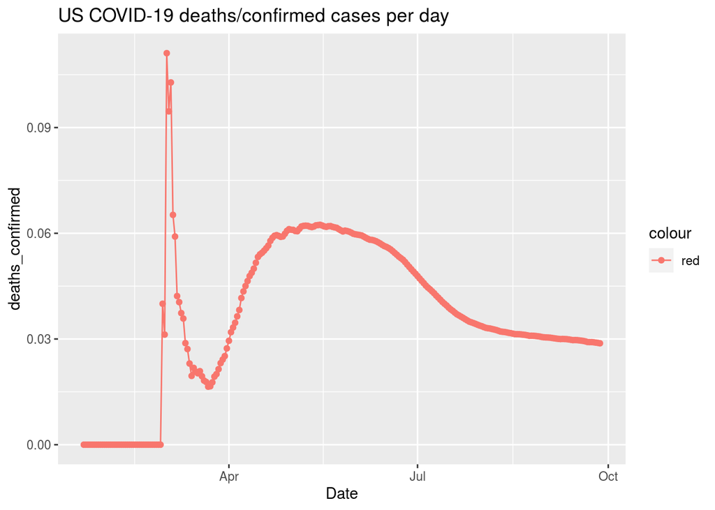

```r
time_series_deaths_confirmed %>%
  group_by(Country_Region,Date) %>%
  summarise_at(c("deaths_confirmed"), sum) %>%
  filter (Country_Region == "US") %>%
    ggplot(aes(x = Date,  y = deaths_confirmed, color = "red")) +
    geom_point() +
    geom_line() +
    ggtitle("US COVID-19 deaths/confirmed cases per day")
```

#7. Make a single graph with from the times series data with the 10 countries with the hightest death total.

```r
  time_series_top_10_countries_deaths <- time_series_long_joined %>%
    group_by(Country_Region) %>%
    summarize(total_deaths = sum(Deaths)) %>%
    arrange(desc(total_deaths)) %>%
    slice(1:10)
```

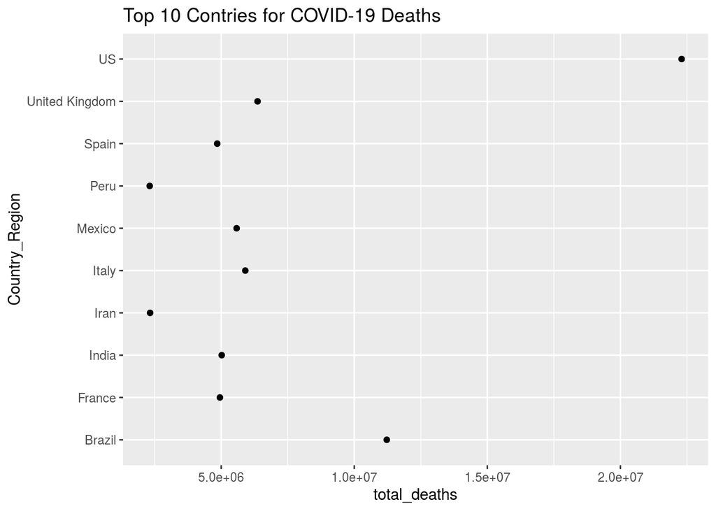

```r
ggplot(data = time_series_top_10_countries_deaths, aes(x = total_deaths, y = Country_Region)) +
  geom_point() +
  ggtitle("Top 10 Contries for COVID-19 Deaths")
```

#8. Using Facet_Wraps make a graph from the times series data with the 10 countries with the hightest death total. Format the table to look nice in the report by changing the number of rows in your graph and/or adjusting the height in the R code chunk header.

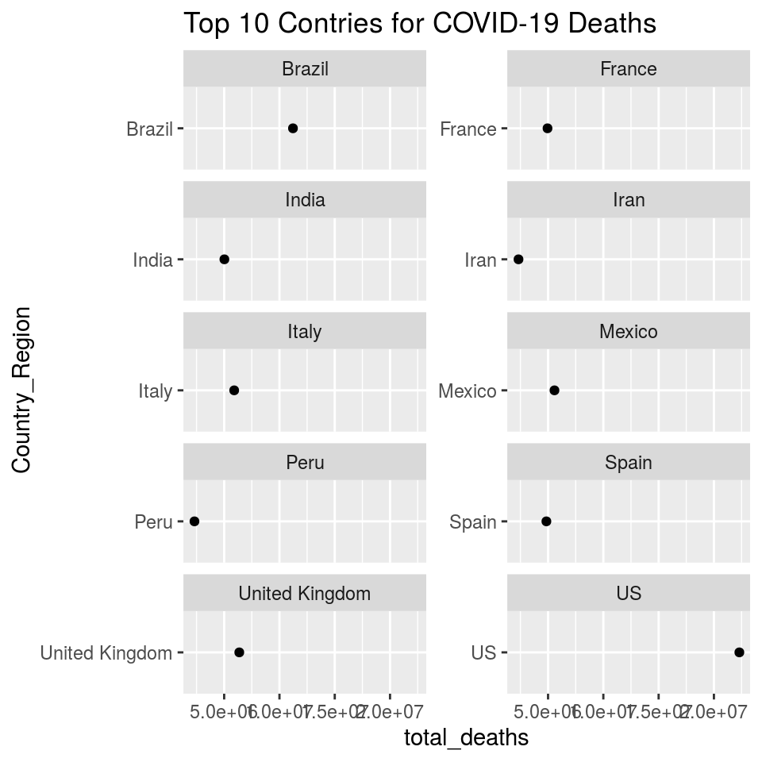

```r
ggplot(data = time_series_top_10_countries_deaths, aes(x = total_deaths, y = Country_Region)) +
  geom_point() +
  ggtitle("Top 10 Contries for COVID-19 Deaths") +
  facet_wrap(~Country_Region, ncol=2, scales="free_y")
```

```r
  time_series_US_confirmed <- time_series_long_joined %>%
    filter(Country_Region == "US") %>%
    group_by(Province_State)
```

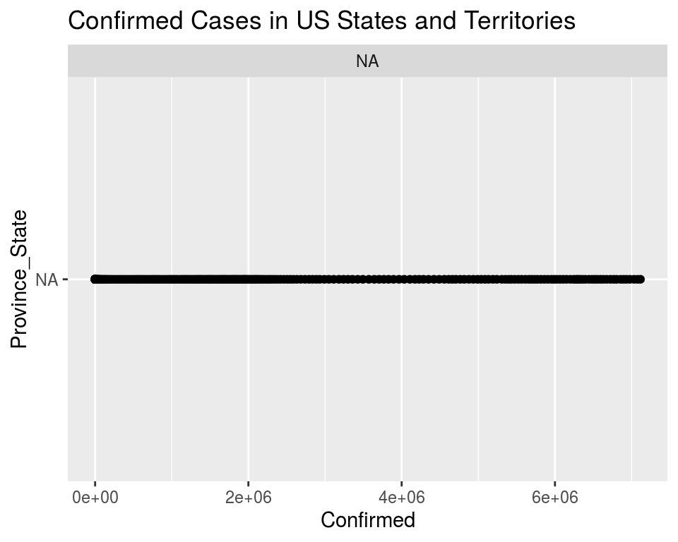

```r
ggplot(data = time_series_US_confirmed, aes(x = Confirmed, y = Province_State)) +
  geom_point() +
  ggtitle("Confirmed Cases in US States and Territories") +
  facet_wrap(~Province_State, ncol=5, scales="free_y")
```

#10. Apply a theme other than the one used in the Data Carpentries tutorial to the graph in Ex8.

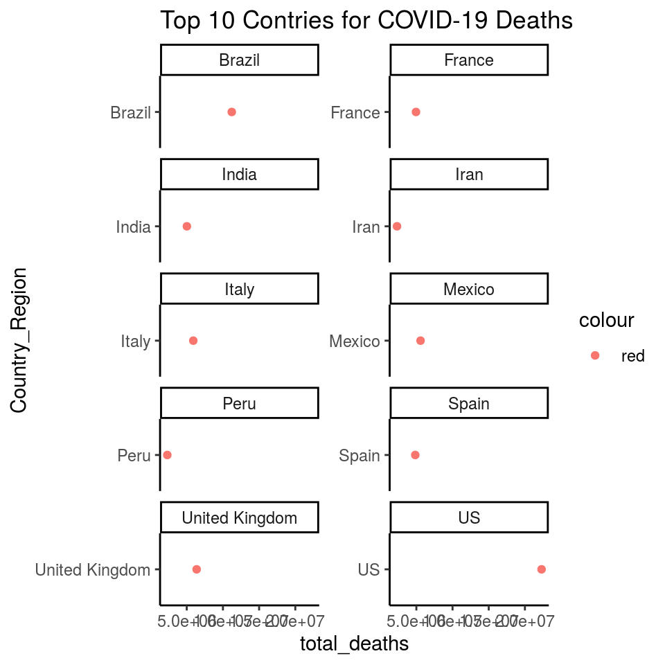

```r
ggplot(data = time_series_top_10_countries_deaths, mapping = aes(x = total_deaths, y = Country_Region, color = "red")) +
  geom_point() +
  ggtitle("Top 10 Contries for COVID-19 Deaths") +
  facet_wrap(~Country_Region, ncol=2, scales="free_y") +
  theme_classic()
```